# Actividad 2: Modelo SIR

E. Crescio, J. Montalvo, E. Uresti

Noviembre de 2020

## El modelo SIR

Consideremos un modelo para describir la dinámica de un grupo de individuos de una población con exposición a una enfermedad que puede contagiarse entre los miembros de la población. Esto puede modelarse como un sistema dinámico denominado $SIR$ para una población de $N$ individuos en la que se considera la interacción entre un conjunto de $S$ individuos *suceptibles* de contraer la enfermedad, un conjunto $I$ de individuos *infectados* y uno conjunto $R$ de individuos *recuperados* de la enfermedad.

Este modelo tiene los siguientes supuestos:

- la probabilidades de infectarse son iguales para todos los individuos de la población;
- la población es homogénea, es decir que los riesgos de infectarse son iguales para toos los suceptibles y que los tiempos para recuperarse son iguales para todos los infectados; y
- el tamaño $N$ de la población es constante.

El modelo maneja los diferentes conjuntos $S$, $I$ y $R$ como si fueran compartimentos bien separados y considera que los individuos pueden pasr de uno a otro en el caso de que se enfermen (cambio $S\rightarrow I$) o que una vez enfermos se recuperen (cambio $I\rightarrow$). Ademas, se asume que un individuo no puede pasar del conjunto de suceptibles directamente al conjunto de recuperados.

Con estos supuestos y consideraciones, las ecuaciones diferenciales del modelo SIR son:
$$\begin{aligned}
\frac{dS}{dt}&= -\beta \frac{I}{N} S\\
\frac{dI}{dt}&= \beta\frac{I}{N}S-\gamma I\\\
\frac{dR}{dt}&= \gamma I
\end{aligned}$$
donde:

- N=S+R+I
- la cantidad $\beta\frac{I}{N}$ representa la razón con que las personas salen del compartimento S (se infectan);
- en la primera ecuación $dS$ representa el cambio debido a las personas que salen del compartimento $S$ (el signo negativo se debe a que las personas salen)
- en la segunda ecuación $dI$ representa el cambio debido a las personas que salen del compartimento $I$ (una parte se debe a las personas que del compartimento $S$ pasan al compartimento $I$, y otra parte se debe a las personas que salen del compartimento $I$ porque se recuperan);
- la cantidad $\gamma$ representa la razón con que las personas se recuperan.

```r
# PACKAGES:
library(deSolve)
library(reshape2)
library(ggplot2)


initial_state_values <- c(S = 999999,  # Número de susceptibles inicial
                                       #
                          I = 1,       # Se inicia con una persona infectada
                          R = 0)       #


#razones en unidades de días^-1
parameters <- c(beta = 1,      # razón de infección
                gamma = 0.1)   # razón de recuperación

#valores de tiempo para resolver la ecuación, de 0 a 60 días
times <- seq(from = 0, to = 60, by = 1)

sir_model <- function(time, state, parameters) {
    with(as.list(c(state, parameters)), {# R obtendrá los nombres de variables a
                                         # partir de inputs de estados y parametros
        N <- S+I+R
        lambda <- beta * I/N
        dS <- -lambda * S
        dI <- lambda * S - gamma * I
        dR <- gamma * I
        return(list(c(dS, dI, dR)))
    })
}

# poner la solución del sistema de ecuaciones en forma de un dataframe
output <- as.data.frame(ode(y = initial_state_values,
                            times = times,
                            func = sir_model,
                            parms = parameters))
```

## Gráficos de la evolución del sistema

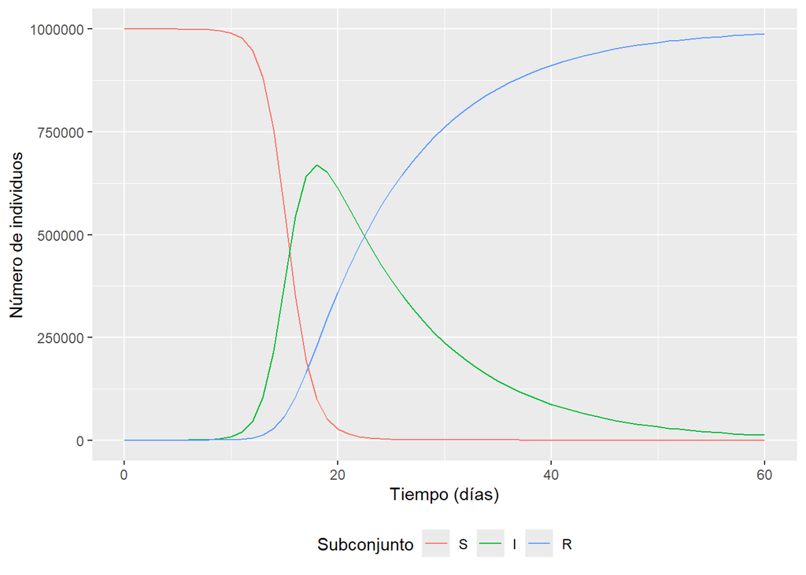

```r
output_long <- melt(as.data.frame(output), id = "time")

ggplot(data = output_long,
       aes(x = time, y = value, colour = variable, group = variable)) +
  geom_line() +
  xlab("Tiempo (días)")+
  ylab("Número de individuos") +
  labs(colour = "Subconjunto") +
  theme(legend.position = "bottom")
```

Con el modelo SIR se define la constante
$$R_0=\frac{\beta}{\gamma}$$
que representa el número de personas que cada contagiado infecta. Para que la enfermedad analizada logre dispararse en forma de una epidemia debe cumplirse que $R_0 > 1$.

También se define
$$R_{eff}=R_0\frac{S}{N}$$
que corresponde al número promedio de personas que cada contagiado infecta. Este segundo valor $R_{eff}$ toma en cuenta de que durante la evolución de la pandemia, al aumentar del número de personas inmunes en la población cada persona contagiada infectará a un número de personas cada vez menor.

## Pregunta 1

Haga cambios en el modelo para tomar en cuenta el hecho de que la población no es constante:

- agregar un término de incremento en $dS$ para tomar en cuenta los individuos nacidos $+bN$
- agregar un término de decremento en $dS$ para tomar en cuenta las personas susceptibles que mueren -$\mu S$
- agregar un término de decremento en $dI$ para tomar en cuenta las personas infectadas que mueren -$\mu I$
- agregar un término de decremento en $dR$ para tomar en cuenta las personas recuperadas que fallecen $-\mu R$

```r
initial_state_values <- c(S = 999999,  # Número de susceptibles inicial
                                       #
                          I = 1,       # Se inicia con una persona infectada
                          R = 0)       #


#razones en unidades de días^-1
parameters_new <- c(beta = 0.4 * 365,      # razón de infección
                gamma = 0.1 * 365,
                mu = 1 / 70,
                b = 1 / 70
                )

#valores de tiempo para resolver la ecuación, de 0 a 60 días
times_new <- seq(from = 0, to = 1, by = 1 / 365)

sir_model_new <- function(time, state, parameters) {
    with(as.list(c(state, parameters)), {# R obtendrá los nombres de variables a
                                         # partir de inputs de estados y parametros
        N <- S+I+R
        lambda <- beta * I/N
        dS <- -lambda * S + b*N - mu* S
        dI <- lambda * S - gamma * I - mu*I
        dR <- gamma * I - mu * R

        return(list(c(dS, dI, dR)))
    })
}

# poner la solución del sistema de ecuaciones en forma de un dataframe
output_new <- as.data.frame(ode(y = initial_state_values,
                            times = times_new,
                            func = sir_model_new,
                            parms = parameters_new))
```

## Gráficos de la evolución del sistema

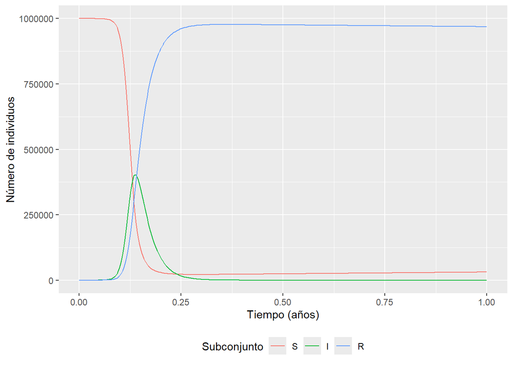

```r
output_long_new <- melt(as.data.frame(output_new), id = "time")

ggplot(data = output_long_new,
       aes(x = time, y = value, colour = variable, group = variable)) +
  geom_line() +
  xlab("Tiempo (años)")+
  ylab("Número de individuos") +
  labs(colour = "Subconjunto") +
  theme(legend.position = "bottom")
```

## Pregunta 2

Considerando el modelo SIR básico, haga cambios para tomar en cuenta un programa de vacunación. Suponga que una fracción $v$ de susceptibles se vacuna de manera que queda inmune (y entra ahora directamente en el conjunto de los recuperados). Calcule la dinámica de la epidemia en este caso usando los parámetros $\beta=0.4$, $\gamma=0.1$ y considere un periodo de 2 años.

Su modelo debe ser capaz de mostrar que si la fracción $v$ es suficiente, no es necesario vacunar a todos los suceptibles para evitar la epidemia. A este efecto se le conoce como *inmunidad de rebaño* y se refiere a que si un sector grande de la población es inmune, entonces los contagios se mantienen a un nivel en el que la enfermedad es eliminada.

¿Cómo se puede calcular la fracción mínima $v$ de personas que se deben vacunar para poder evitar una epidemia? La inmunidad de rebaño ocurre cuando $R_{eff}< 1$.

$$\begin{aligned}
\therefore
\\
R_{eff} &= R_0\frac{S}{N} \\
\end{aligned}$$

$$\begin{aligned}
R_{eff} = 1 &= R_0\frac{S}{N} \\
\end{aligned}$$
]

$$\begin{aligned}
\therefore\\
1 = R_{eff} &= R_0 \frac{S_{new}}{N}\\
1 = R_{eff} &= \frac{\beta}{\gamma} \frac{(N-1) (1 - v)}{N}\\
1 &= \frac{\beta}{\gamma} \frac{N-vN-1+v}{N}\\
\frac{\gamma}{\beta} &= 1 - v - \frac{1}{N} + \frac{v}{N} \\
\frac{\gamma}{\beta} &= v(-1 + \frac{1}{N}) + 1 - \frac{1}{N} \\
\frac{\gamma}{\beta} - 1 + \frac{1}{N} &= v(-1 + \frac{1}{N}) \\
\frac{\frac{\gamma}{\beta} - 1 + \frac{1}{N}}{-1 + \frac{1}{N}}
&= v\\
\therefore \\
v &> \frac{\frac{\gamma}{\beta} - 1 + \frac{1}{N}}{-1 +
\frac{1}{N}}
\end{aligned}$$
Calculating the number we have:

```python
gamma = 0.1
beta = 0.4
N = 1000000

denom = -1 + 1 / N

v = (gamma / beta - 1 + 1 / N) / denom
print(v)
```

```
## 0.7499997499997499
```

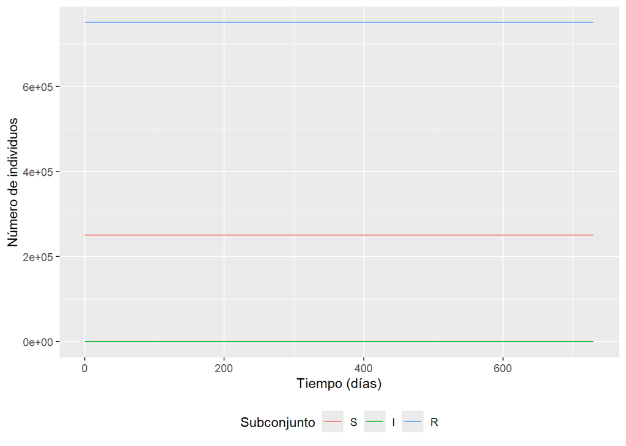

```r
library(reticulate)

# To simulate instant vaccination program we can re-use the previous SIR provided code
v <- py$v
N_0 <- 1000000
initial_state_values <- c(S = (N_0 - 1)*(1-v),  # Número de susceptibles inicial
                                       #
                          I = 1,       # Se inicia con una persona infectada
                          R = (N_0-1)*(v))

parameters <- c(beta = 0.4,      # razón de infección
                gamma = 0.1)   # razón de recuperación

times <- seq(from = 0, to = 365 * 2, by = 1)

output <- as.data.frame(ode(y = initial_state_values,
                            times = times,
                            func = sir_model,
                            parms = parameters))

output_long <- melt(as.data.frame(output), id = "time")

ggplot(data = output_long,
       aes(x = time, y = value, colour = variable, group = variable)) +
  geom_line() +
  xlab("Tiempo (días)")+
  ylab("Número de individuos") +
  labs(colour = "Subconjunto") +
  theme(legend.position = "bottom")
```

It is also worthy to note the I’ behaviour at the equilibrium point (When $R_{eff} = 1$) when $R_{eff_0} > 1$)
$$\begin{aligned}
R_{eff} &= \frac{\beta}{\gamma + \mu} \frac{S(t)}{N(t)} \therefore
R_{eff} \frac{\gamma + \mu}{\beta} = \frac{S(t)}{N(t)}\\
\frac{dI}{dt} &= \beta \frac{I}{N}S - I (\gamma + \mu) \\
\frac{dI}{dt} &= \beta I(\frac{\gamma + \mu}{\beta}) - I (\gamma +
\mu)\\
\frac{dI}{dt} &= I(\gamma + \mu) - I(\gamma + \mu) = 0\\
\textit{As a result we get that $I(t_{eq})$ is maximum $ \mid
R_{eff}(t_{eq}) = 1$}\\
\end{aligned}$$

## Pregunta 3

Haga cambios en el modelo para tomar en cuenta de que la población no es constante:

- agregar un término de incremento en $dS$ para tomar en cuenta los nacidos $+bN$
- agregar un término de decremento en $dS$ para tomar en cuenta las personas susceptibles que mueren -$\mu S$
- agregar un término de decremento en $dI$ para tomar en cuenta las personas infectadas que mueren -$\mu I$
- agregar un término de decremento en $dR$ para tomar en cuenta las personas recuperadas que fallecen $-\mu R$

Use los parámetros
$$\begin{aligned}
\beta &= 0.4 days^{-1} &= (0.4 \times 365) years^{-1}\\
\gamma &= 0.2 days^{-1} &= (0.2 \times 365) years^{-1}\\
\mu &= \frac{1}{70}years^{-1}\\
b &= \frac{1}{70}years^{-1}\\
\end{aligned}$$
y considere una duración de 400 años en sus cálculos.

```r
initial_state_values <- c(S = 999999,  # Número de susceptibles inicial
                                       #
                          I = 1,       # Se inicia con una persona infectada
                          R = 0)       #


parameters_new <- c(beta = 0.4 * 365,      # razón de infección
                gamma = 0.2 * 365,
                mu = 1/70,
                b = 1 / 70
                )

#valores de tiempo para resolver la ecuación, de 0 a 4 años
times_new <- seq(from = 0, to = 400, by = 1 / 365)

sir_model_new <- function(time, state, parameters) {
    with(as.list(c(state, parameters)), {# R obtendrá los nombres de variables a
                                         # partir de inputs de estados y parametros
        N <- S+I+R
        lambda <- beta * I/N
        dS <- -lambda * S + b*N - mu* S
        dI <- lambda * S - gamma * I - mu*I
        dR <- gamma * I - mu * R

        return(list(c(dS, dI, dR)))
    })
}

# poner la solución del sistema de ecuaciones en forma de un dataframe
output_new <- as.data.frame(ode(y = initial_state_values,
                            times = times_new,
                            func = sir_model_new,
                            parms = parameters_new))
```

## Gráficos de la evolución del sistema

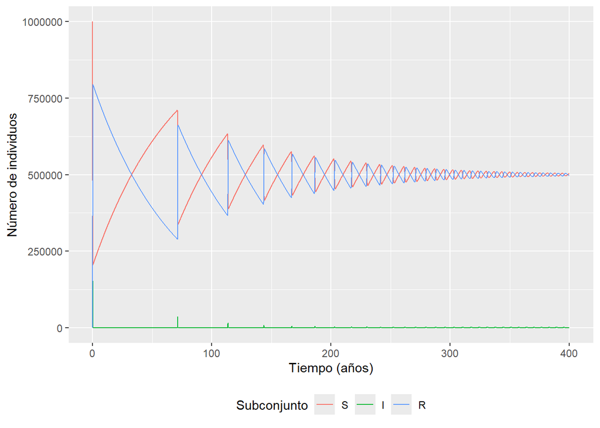

```r
output_long_new <- melt(as.data.frame(output_new), id = "time")

ggplot(data = output_long_new,
       aes(x = time, y = value, colour = variable, group = variable)) +
  geom_line() +
  xlab("Tiempo (años)")+
  ylab("Número de individuos") +
  labs(colour = "Subconjunto") +
  theme(legend.position = "bottom")
```

## Pregunta 4

Considerando el modelo SIR básico, haga cambios para tomar en cuenta un programa de vacunación. Suponga que una fracción $v$ de susceptibles se vacuna de manera que queda inmune (y entra ahora directamente en el conjunto de los recuperados), mientras que la fracción $(1-v)$ sigue siendo susceptible.

Calcule la dinámica de la epidemia en este caso, estudiando cómo cambia la dinámica variando la fracción $v$. Utilice $\beta=0.6$, $\gamma=0.1$ y considere un periodo de 2 años.

Su modelo debe ser capaz de mostrar que si la fracción $v$ es suficiente, no es necesario vacunar a todos los suceptibles para evitar la epidemia. A este efecto se le conoce como *inmunidad de rebaño* y se refiere a que si un sector grande de la población es inmune, entonces los contagios se mantienen a un nivel en el que la enfermedad es eliminada.

¿Cómo se puede calcular la fracción mínima $v$ de personas que se deben vacunar para poder evitar una epidemia? La inmunidad de rebaño ocurre cuando $R_{eff}< 1$.

Retomando nuestro resultado anterior, obtenemos el valor crítico:

```python
gamma = 0.1
beta = 0.6
N = 1000000

denom = -1 + 1 / N

v = (gamma / beta - 1 + 1 / N) / denom
print(v)
```

```
## 0.8333331666664999
```

```r
parameters <- c(beta = 0.6,      # razón de infección
                gamma = 0.1)   # razón de recuperación
times <- seq(from = 0, to = 365 * 2, by = 1)

N_0 <- 1000000
v <- 1 / 50
print(v)
```

```
## [1] 0.02
```

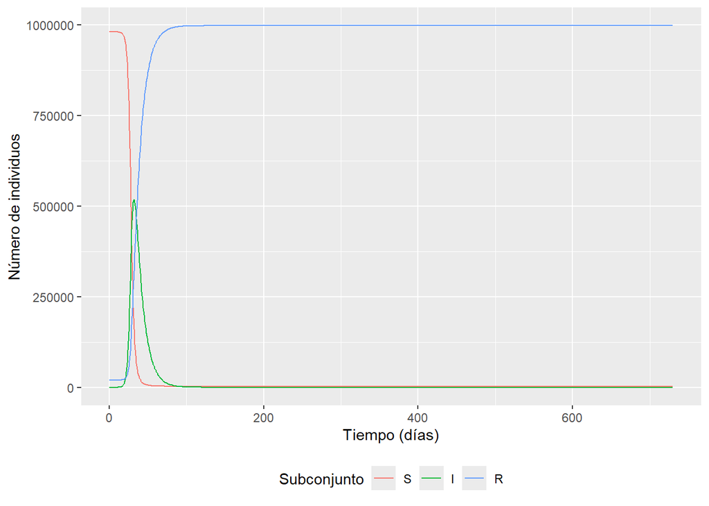

```r
initial_state_values <- c(S = (N_0 - 1)*(1-v),  # Número de susceptibles inicial
                                       #
                          I = 1,       # Se inicia con una persona infectada
                          R = (N_0-1)*(v))

output <- as.data.frame(ode(y = initial_state_values,
                            times = times,
                            func = sir_model,
                            parms = parameters))

output_long <- melt(as.data.frame(output), id = "time")

ggplot(data = output_long,
       aes(x = time, y = value, colour = variable, group = variable)) +
  geom_line() +
  xlab("Tiempo (días)")+
  ylab("Número de individuos") +
  labs(colour = "Subconjunto") +
  theme(legend.position = "bottom")
```

```r
v <- 1 / 10
print(v)
```

```
## [1] 0.1
```

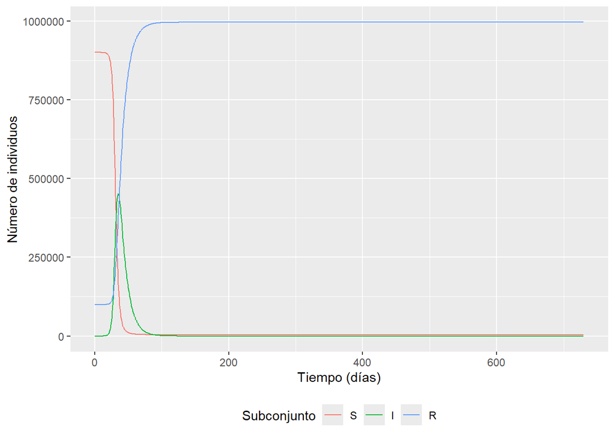

```r
initial_state_values <- c(S = (N_0 - 1)*(1-v),  # Número de susceptibles inicial
                                       #
                          I = 1,       # Se inicia con una persona infectada
                          R = (N_0-1)*(v))

output <- as.data.frame(ode(y = initial_state_values,
                            times = times,
                            func = sir_model,
                            parms = parameters))

output_long <- melt(as.data.frame(output), id = "time")

ggplot(data = output_long,
       aes(x = time, y = value, colour = variable, group = variable)) +
  geom_line() +
  xlab("Tiempo (días)")+
  ylab("Número de individuos") +
  labs(colour = "Subconjunto") +
  theme(legend.position = "bottom")
```

```r
v <- 1 / 5
print(v)
```

```
## [1] 0.2
```

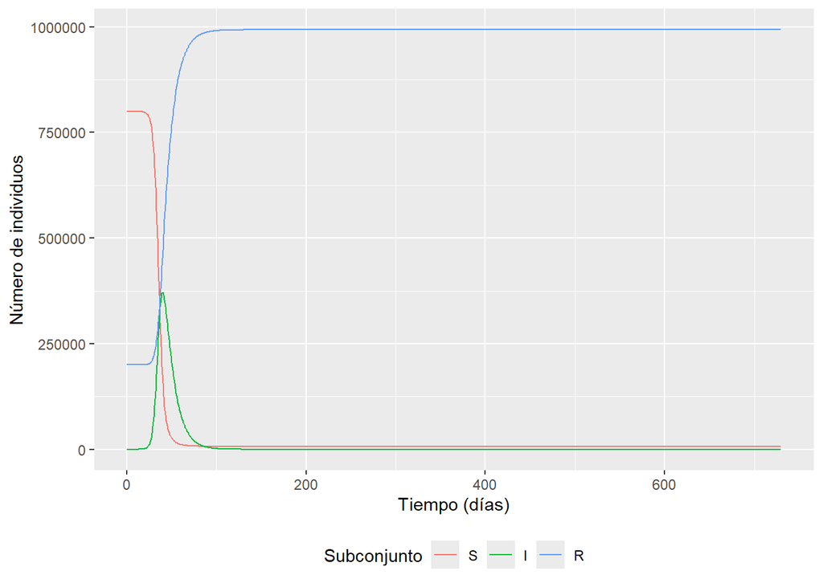

```r
initial_state_values <- c(S = (N_0 - 1)*(1-v),  # Número de susceptibles inicial
                                       #
                          I = 1,       # Se inicia con una persona infectada
                          R = (N_0-1)*(v))

output <- as.data.frame(ode(y = initial_state_values,
                            times = times,
                            func = sir_model,
                            parms = parameters))

output_long <- melt(as.data.frame(output), id = "time")

ggplot(data = output_long,
       aes(x = time, y = value, colour = variable, group = variable)) +
  geom_line() +
  xlab("Tiempo (días)")+
  ylab("Número de individuos") +
  labs(colour = "Subconjunto") +
  theme(legend.position = "bottom")
```

```r
v <- 1 / 3
print(v)
```

```
## [1] 0.3333333
```

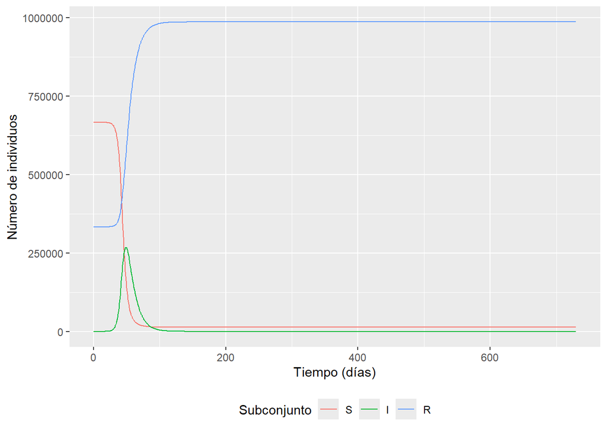

```r
initial_state_values <- c(S = (N_0 - 1)*(1-v),  # Número de susceptibles inicial
                                       #
                          I = 1,       # Se inicia con una persona infectada
                          R = (N_0-1)*(v))

output <- as.data.frame(ode(y = initial_state_values,
                            times = times,
                            func = sir_model,
                            parms = parameters))

output_long <- melt(as.data.frame(output), id = "time")

ggplot(data = output_long,
       aes(x = time, y = value, colour = variable, group = variable)) +
  geom_line() +
  xlab("Tiempo (días)")+
  ylab("Número de individuos") +
  labs(colour = "Subconjunto") +
  theme(legend.position = "bottom")
```

```r
v <- 1 / 2
print(v)
```

```
## [1] 0.5
```

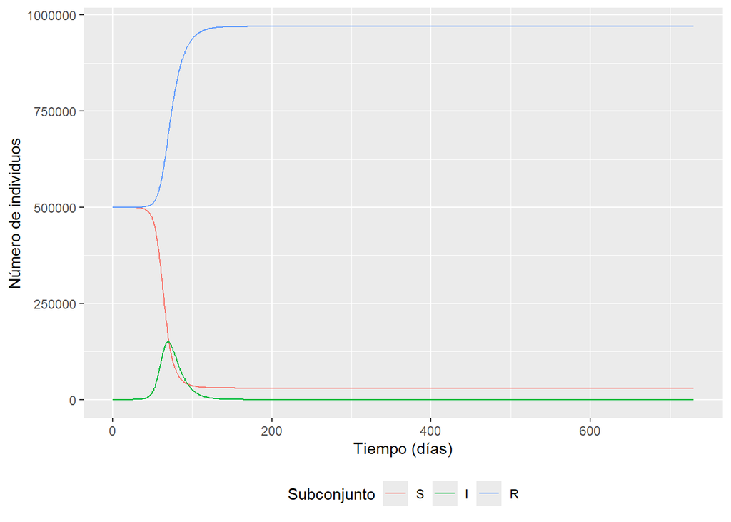

```r
initial_state_values <- c(S = (N_0 - 1)*(1-v),  # Número de susceptibles inicial
                                       #
                          I = 1,       # Se inicia con una persona infectada
                          R = (N_0-1)*(v))

output <- as.data.frame(ode(y = initial_state_values,
                            times = times,
                            func = sir_model,
                            parms = parameters))

output_long <- melt(as.data.frame(output), id = "time")

ggplot(data = output_long,
       aes(x = time, y = value, colour = variable, group = variable)) +
  geom_line() +
  xlab("Tiempo (días)")+
  ylab("Número de individuos") +
  labs(colour = "Subconjunto") +
  theme(legend.position = "bottom")
```

```r
v <- 2 / 3
print(v)
```

```
## [1] 0.6666667
```

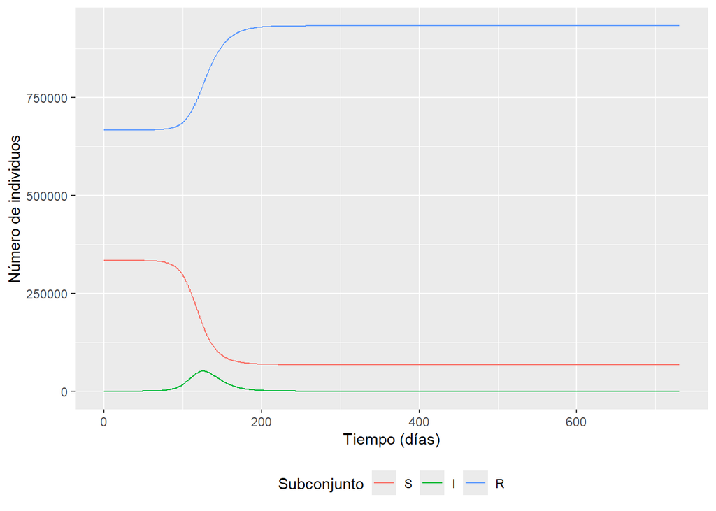

```r
initial_state_values <- c(S = (N_0 - 1)*(1-v),  # Número de susceptibles inicial
                                       #
                          I = 1,       # Se inicia con una persona infectada
                          R = (N_0-1)*(v))

output <- as.data.frame(ode(y = initial_state_values,
                            times = times,
                            func = sir_model,
                            parms = parameters))

output_long <- melt(as.data.frame(output), id = "time")

ggplot(data = output_long,
       aes(x = time, y = value, colour = variable, group = variable)) +
  geom_line() +
  xlab("Tiempo (días)")+
  ylab("Número de individuos") +
  labs(colour = "Subconjunto") +
  theme(legend.position = "bottom")
```

Ahora usamos el valor crítico obtenido con python

```r
v <- py$v
print(v)
```

```
## [1] 0.8333332
```

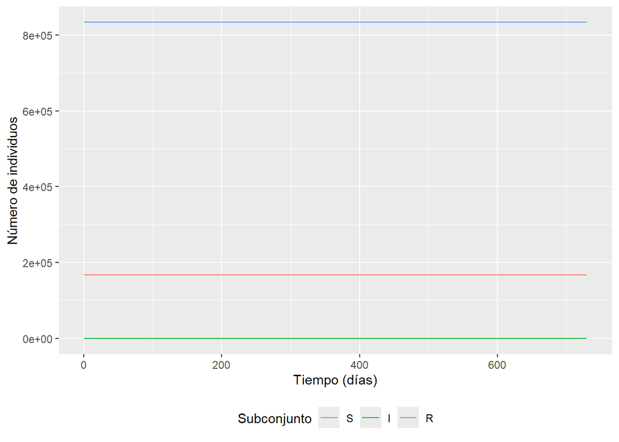

```r
initial_state_values <- c(S = (N_0 - 1)*(1-v),  # Número de susceptibles inicial
                                       #
                          I = 1,       # Se inicia con una persona infectada
                          R = (N_0-1)*(v))

output <- as.data.frame(ode(y = initial_state_values,
                            times = times,
                            func = sir_model,
                            parms = parameters))

output_long <- melt(as.data.frame(output), id = "time")

ggplot(data = output_long,
       aes(x = time, y = value, colour = variable, group = variable)) +
  geom_line() +
  xlab("Tiempo (días)")+
  ylab("Número de individuos") +
  labs(colour = "Subconjunto") +
  theme(legend.position = "bottom")
```

Comprobando así que es solo a partir de este valor que se evita la epidemia